# Predictive Analysis of Nitrogen Levels Using Microbial ASVs

2025-03-27

```r
# Load required packages
library(phyloseq)
library(dplyr)
library(randomForest)
library(caret)
# Load phyloseq object
load("physeq_wl.RData")
physeq  # check object loaded correctly
```

```
## phyloseq-class experiment-level object
## otu_table()   OTU Table:         [ 143942 taxa and 192 samples ]
## sample_data() Sample Data:       [ 192 samples by 44 sample variables ]
## tax_table()   Taxonomy Table:    [ 143942 taxa by 2 taxonomic ranks ]
```

```r
# Extract OTU table as a dataframe (samples as rows)
otu_df <- as.data.frame(t(otu_table(physeq)))

# Extract sample metadata explicitly (CRITICAL STEP!)
metadata <- as.data.frame(sample_data(physeq))

# Load ISA and overlap ASVs
isa_df <- read.csv("Core_micb_indx_taxa/ISA_nitrogen_IW.csv")
low_core <- read.csv("Core_micb_indx_taxa/overlap_tax_low.csv")
high_core <- read.csv("Core_micb_indx_taxa/overlap_tax_high.csv")

core_indicator_ids <- union(low_core$ASV, high_core$ASV)

filtered_isa <- isa_df %>%
  filter(
    ASV %in% core_indicator_ids,
    stat >= 0.8,
    (s.low == 1 & s.high == 0) | (s.low == 0 & s.high == 1)
  )

# Selected ASVs
selected_asvs <- filtered_isa$ASV
print(selected_asvs)
```

```
## [1] "c59768a0cba53f0e1141c9ba541b6cbc" "8d20b5539f7ea093b96ad0bf482a2d34"
## [3] "0a41bf6851bcce501e9fb0c8806e876d" "7b0d6970e21ed778b162be105e626557"
## [5] "4ed91d931cafdca8362e8bfe1e90dab3" "6b6af0c4ef7dc65b8c044a370146ada0"
## [7] "11334291947eca314219c89eb5ab301c" "1d9fd315edccf1f2541d8b0a589ff1e9"
```

```r
# Subset OTU table to selected ASVs
otu_select <- otu_df[, selected_asvs]


# Clearly define High and Low nitrogen categories:
# Use explicit categories based on original metadata values
metadata$Nitrogen_Class <- ifelse(metadata$total_nitrogen_percent == "high", "High",
                           ifelse(metadata$total_nitrogen_percent == "low", "Low", NA))


# Keep only samples with clear nitrogen class
valid_idx <- !is.na(metadata$Nitrogen_Class)
metadata_filt <- metadata[valid_idx, ]
otu_select_filt <- otu_df[valid_idx, selected_asvs]

# Final model data frame (features + target)
model_data <- cbind(Nitrogen_Class = metadata_filt$Nitrogen_Class, otu_select_filt)

# Verify resulting table
table(model_data$Nitrogen_Class)
```

```
##
## High  Low
##   54  138
```

```r
head(model_data)
```

```
##        Nitrogen_Class c59768a0cba53f0e1141c9ba541b6cbc
## X382.0            Low                                0
## X0.0              Low                                0
## X0.0.1            Low                                0
## X0.0.2            Low                               13
## X0.0.3            Low                                0
## X0.0.4            Low                                0
##        8d20b5539f7ea093b96ad0bf482a2d34 0a41bf6851bcce501e9fb0c8806e876d
## X382.0                                0                                0
## X0.0                                  0                               34
## X0.0.1                                0                                0
## X0.0.2                              197                                0
## X0.0.3                              103                                0
## X0.0.4                                0                                0
##        7b0d6970e21ed778b162be105e626557 4ed91d931cafdca8362e8bfe1e90dab3
## X382.0                                0                               21
## X0.0                                  0                                0
## X0.0.1                                0                                0
## X0.0.2                                0                                0
## X0.0.3                                0                                0
## X0.0.4                                0                                0
##        6b6af0c4ef7dc65b8c044a370146ada0 11334291947eca314219c89eb5ab301c
## X382.0                                0                               15
## X0.0                                  0                               44
## X0.0.1                                0                               44
## X0.0.2                                0                               53
## X0.0.3                                0                               56
## X0.0.4                                0                                0
##        1d9fd315edccf1f2541d8b0a589ff1e9
## X382.0                               13
## X0.0                                  0
## X0.0.1                               19
## X0.0.2                                0
## X0.0.3                                0
## X0.0.4                                0
```

```r
# Explicitly set Nitrogen_Class as factor (CRITICAL FIX!)
model_data$Nitrogen_Class <- factor(model_data$Nitrogen_Class, levels = c("Low", "High"))

set.seed(123)  # reproducibility
train_idx <- createDataPartition(model_data$Nitrogen_Class, p = 0.7, list = FALSE)

train_data <- model_data[train_idx, ]
test_data  <- model_data[-train_idx, ]

# Fix column names to valid R identifiers
colnames(train_data) <- make.names(colnames(train_data))
colnames(test_data) <- make.names(colnames(test_data))




# Verify class distribution
cat("Train class distribution:\n")
```

```
## Train class distribution:
```

```r
print(prop.table(table(train_data$Nitrogen_Class)))
```

```
##
##       Low      High
## 0.7185185 0.2814815
```

```r
cat("Test class distribution:\n")
```

```
## Test class distribution:
```

```r
print(prop.table(table(test_data$Nitrogen_Class)))
```

```
##
##       Low      High
## 0.7192982 0.2807018
```

# 2. Random Forest Model Training (500 trees)

```r
set.seed(123)  # reproducibility
rf_model <- randomForest(Nitrogen_Class ~ .,
                         data = train_data,
                         ntree = 500,
                         importance = TRUE,
                         proximity = TRUE)

print(rf_model)
```

```
##
## Call:
##  randomForest(formula = Nitrogen_Class ~ ., data = train_data,      ntree = 500, importance = TRUE, proximity = TRUE)
##                Type of random forest: classification
##                      Number of trees: 500
## No. of variables tried at each split: 2
##
##         OOB estimate of  error rate: 11.11%
## Confusion matrix:
##      Low High class.error
## Low   94    3  0.03092784
## High  12   26  0.31578947
```

# 3. Model Evaluation (Accuracy and Confusion Matrix)

Evaluate the model using both training and testing datasets.

```r
# Predictions on training set
train_pred <- predict(rf_model, train_data)
train_cm <- confusionMatrix(train_pred, train_data$Nitrogen_Class)
cat("Training Accuracy:", train_cm$overall["Accuracy"], "\n")
```

```
## Training Accuracy: 0.962963
```

```r
print(train_cm$table)
```

```
##           Reference
## Prediction Low High
##       Low   97    5
##       High   0   33
```

```r
# Predictions on test set
test_pred <- predict(rf_model, test_data)
test_cm <- confusionMatrix(test_pred, test_data$Nitrogen_Class)
cat("Test Accuracy:", test_cm$overall["Accuracy"], "\n")
```

```
## Test Accuracy: 0.9122807
```

```r
print(test_cm$table)
```

```
##           Reference
## Prediction Low High
##       Low   41    5
##       High   0   11
```

# 4. Visualization of Model Results

Variable Importance plot: The plot identifies which ASVs are most influential in predicting nitrogen class.

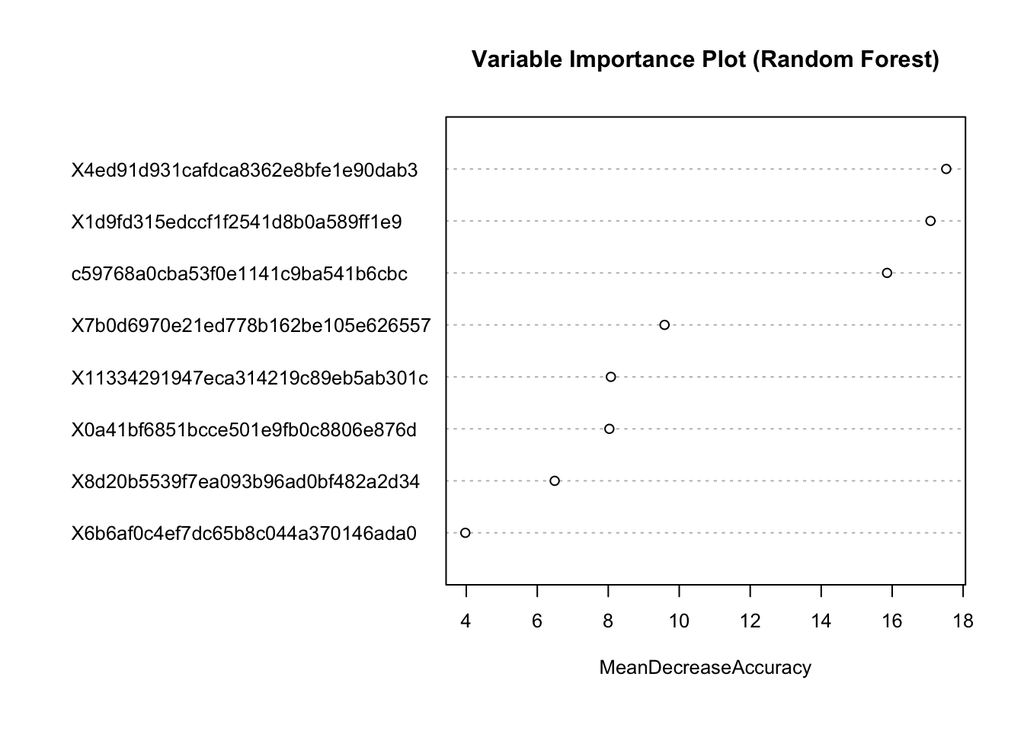

```r
# Adjust margins to clearly display long ASV IDs
par(mar=c(5, 12, 4, 2))

# Plot variable importance horizontally (better readability)
varImpPlot(rf_model,
           main = "Variable Importance Plot (Random Forest)",
           type = 1,            # 1 = Mean Decrease Accuracy only (cleaner)
           cex = 0.8,           # Smaller text size
           horiz = TRUE,        # Horizontal bar plot
           las = 1)             # Horizontal labels
```

```r
# Reset to default margins afterward
par(mar=c(5,4,4,2))
```

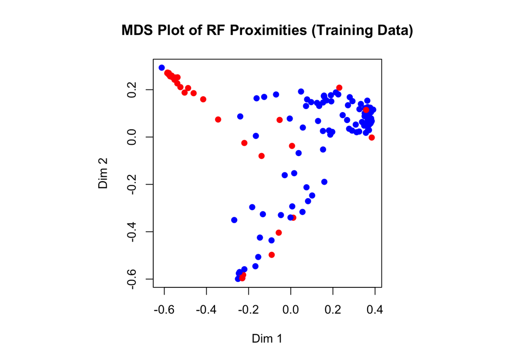

```r
MDSplot(rf_model, train_data$Nitrogen_Class,
        palette=c("blue", "red"), pch=19,
        main="MDS Plot of RF Proximities (Training Data)")
```

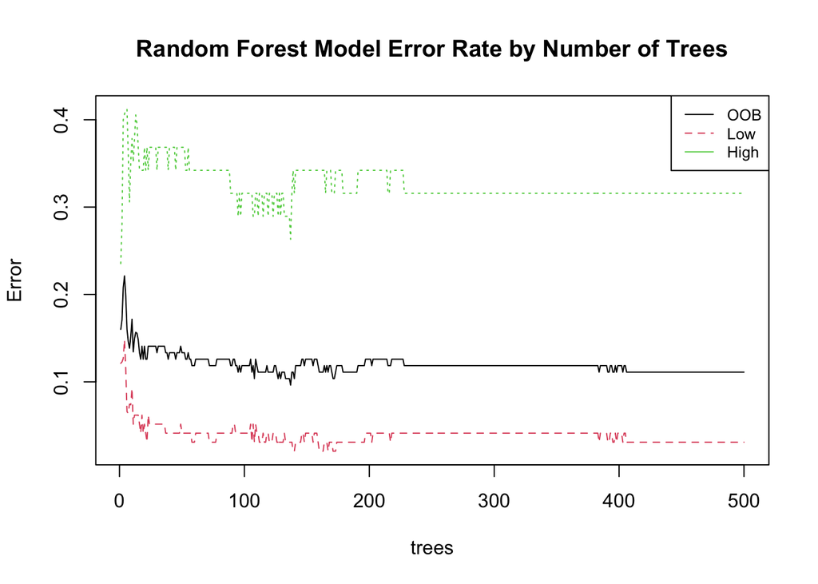

```r
# Basic RF plot for error rates and class separability visualization
plot(rf_model, main="Random Forest Model Error Rate by Number of Trees")
legend("topright", legend = colnames(rf_model$err.rate),
       col=1:ncol(rf_model$err.rate), lty=1:2, cex=0.8)
```

### Note on Class Imbalance

```r
# Choose the top 200 most abundant ASVs for practical full-set comparison
asv_sums <- colSums(otu_df[valid_idx, ])
top_asvs <- names(sort(asv_sums, decreasing = TRUE)[1:200])

# Prepare dataset with selected top ASVs
full_otu_data_small <- cbind(Nitrogen_Class = metadata_filt$Nitrogen_Class,
                             otu_df[valid_idx, top_asvs])

# Ensure factor again explicitly
full_otu_data_small$Nitrogen_Class <- factor(full_otu_data_small$Nitrogen_Class, levels = c("Low","High"))

# Fix non-standard column names
colnames(full_otu_data_small) <- make.names(colnames(full_otu_data_small))

# Train/Test split (70%/30%)
set.seed(123)
small_train_idx <- createDataPartition(full_otu_data_small$Nitrogen_Class, p=0.7, list=FALSE)
small_train <- full_otu_data_small[small_train_idx, ]
small_test <- full_otu_data_small[-small_train_idx, ]

# Train RF with the smaller practical set (top 200 ASVs)
rf_small_full <- randomForest(Nitrogen_Class ~ ., data=small_train, ntree=500)

# Evaluate accuracy explicitly
small_test_pred <- predict(rf_small_full, small_test)
small_cm <- confusionMatrix(small_test_pred, small_test$Nitrogen_Class)
cat("Accuracy (Top 200 ASVs):", small_cm$overall["Accuracy"], "\n")
```

```
## Accuracy (Top 200 ASVs): 0.9122807
```

# Introduction

This report outlines the procedure used to assess the predictive power of specific microbial Amplicon Sequence Variants (ASVs) for classifying wetland soil nitrogen availability (High vs Low) using a Random Forest machine learning model. ASVs were selected based on core microbiome and indicator species analysis (ISA).

# Step-by-Step Workflow

## 1. Data and Libraries

### Libraries used:

- `phyloseq`
- `dplyr`
- `randomForest`
- `caret`

### Data:

- Phyloseq object (`physeq_wl.RData`)
- ISA results (`ISA_nitrogen_IW.csv`)
- Overlapping core-indicator ASV lists:
  - Low nitrogen: `overlap_tax_low.csv`
  - High nitrogen: `overlap_tax_high.csv`

## 2. Data Extraction and Pre-processing

The Phyloseq object was loaded, and its OTU table and metadata were extracted explicitly:

- OTU table transposed to have samples as rows, ASVs as columns.
- Sample metadata extracted clearly and explicitly.

## 3. Selection of Indicator ASVs

ASVs that overlapped between the core microbiome analysis (70% prevalence, detection = 0.001) and ISA were explicitly selected:

- Combined low/high ASV lists from `overlap_tax_low.csv` and `overlap_tax_high.csv`.
- Filtered ISA results to retain ASVs with:
  - Indicator value (`stat`) ≥ 0.8.
  - Exclusive association to one nitrogen class (low or high).

### Final ASVs selected:

- c59768a0cba53f0e1141c9ba541b6cbc
- 8d20b5539f7ea093b96ad0bf482a2d34
- 0a41bf6851bcce501e9fb0c8806e876d
- 7b0d6970e21ed778b162be105e626557
- 4ed91d931cafdca8362e8bfe1e90dab3
- 6b6af0c4ef7dc65b8c044a370146ada0
- 11334291947eca314219c89eb5ab301c
- 1d9fd315edccf1f2541d8b0a589ff1e9

## 4. Dataset Preparation for Modeling

- OTU table explicitly filtered to selected ASVs.
- Nitrogen classes (High/Low) explicitly extracted from the metadata.
- Final dataset clearly labeled, yielding 54 High and 138 Low samples.

## 5. Model Training and Evaluation

### Data Splitting:

- Data split explicitly into training (70%) and test (30%) subsets, ensuring representative proportions for both nitrogen classes.

### Random Forest Model:

- Model explicitly trained on training data (500 trees).
- Nitrogen class set as a factor explicitly to ensure classification modeling.

### Model Performance:

- **Training Accuracy** explicitly computed and reported.
- **Test Accuracy** explicitly computed and reported.

## 6. Visualization of Model Performance

### Variable Importance Plot

- Explicitly visualized to show predictive strength of individual ASVs.

### Multidimensional Scaling (MDS) Plot

- Explicit visualization of class separation using proximity measures from the Random Forest model.

### Error Rate Plot

- Visualization of error rates across number of trees, explicitly showing model stability and performance.

## 7. Additional Analysis

### Class Imbalance Noted

The dataset explicitly showed imbalance (138 Low vs 54 High samples). Future analysis may consider balancing techniques.

### Full-ASV Set Modeling Comparison

Due to memory constraints, explicit modeling with all ASVs was impractical. Therefore, the top 200 most abundant ASVs were explicitly selected for comparative modeling:

- A separate Random Forest model explicitly trained on these 200 ASVs.
- Accuracy explicitly compared with the original 8-ASV model.

## 8. Summary and Conclusions

This structured analytical approach supports microbial community analysis as a robust method for assessing environmental nutrient availability.